V The V Lab

# Common ggplot2 Methods: From the Grammar of Graphics to Publication-Ready Plots

A runnable, practical guide in English

**Audience**Readers who can run basic R code

**Scope**15 sections · 20 rendered charts

**Format**Follow in sequence or browse by topic

# 1 How to use this guide

This guide is for readers who can run R code and want a systematic introduction to the **ggplot2 methods used most often in real work**. Every example uses a base R or ggplot2 built-in dataset, so no external data download is required. You can copy each code chunk directly into RStudio.

Think about a plot in this order:

1. **Data**: what does one row represent, and are the variable types correct?
2. **Mapping**: which variables map to x, y, color, fill, size, or group?
3. **Geometric object (geom)**: should observations be shown as points, lines, bars, boxes, or densities?
4. **Statistical transformation (stat)**: show raw values, counts, bins, a smooth, or a summary?
5. **Position and coordinates**: stack, dodge, jitter, or zoom?
6. **Scale**: how should colors, breaks, labels, and transformations appear?
7. **Facets and theme**: how should small multiples and non-data styling be organized?

The core mental model is

```
ggplot(data, aes(…)) + geom_*() +
scale_*() + facet_*() + coord_*() + theme_*()
```

. Each `+` adds or modifies a layer.

## 1.1 Datasets used in this guide

| Dataset | Contents | Typical uses |
| --- | --- | --- |
| `mpg` | Fuel economy and specifications for 1999 and 2008 models | Scatterplots, bars, facets |
| `diamonds` | Specifications and prices for about 54,000 diamonds | Large data, distributions, log scales |
| `economics` | Monthly U.S. economic indicators | Dates and time series |
| `mtcars` | Performance data for 32 cars | Small demonstrations and modeling |

```r
dim(mpg)
```

```
#> [1] 234  11
```

```r
names(mpg)
```

```
#>  [1] "manufacturer" "model"        "displ"        "year"         "cyl"          "trans"
#>  [7] "drv"          "cty"          "hwy"          "fl"           "class"
```

```r
head(mpg, 3)
```

|  | manufacturer | model | displ | year | cyl | trans | drv | cty | hwy | fl | class |
| --- | --- | --- | --- | --- | --- | --- | --- | --- | --- | --- | --- |
| 1 | audi | a4 | 1.8 | 1999 | 4 | auto(l5) | f | 18 | 29 | p | compact |
| 2 | audi | a4 | 1.8 | 1999 | 4 | manual(m5) | f | 21 | 29 | p | compact |
| 3 | audi | a4 | 2.0 | 2008 | 4 | manual(m6) | f | 20 | 31 | p | compact |

# 2 Grammar of graphics fundamentals

## 2.1 The smallest useful plot

`ggplot()` creates the canvas, `aes()` declares mappings from variables to visual properties, and `geom_point()` says to draw one point for each row.

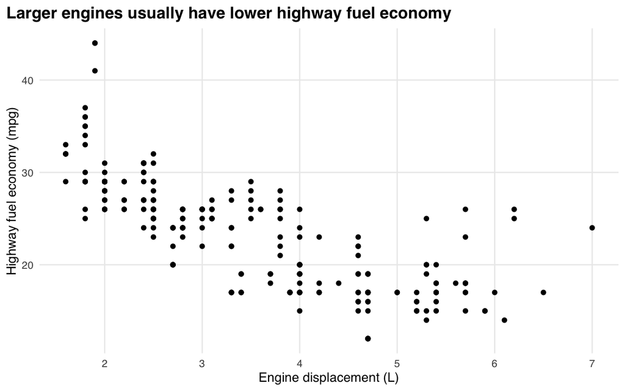

Figure 1: Engine displacement versus highway fuel economy.

```r
ggplot(data = mpg, mapping = aes(x = displ, y = hwy)) +
  geom_point() +
  labs(
    title = "Larger engines usually have lower highway fuel economy",
    x = "Engine displacement (L)",
    y = "Highway fuel economy (mpg)"
  )
```

Data and mappings can also be supplied to individual layers. A global `aes()` is inherited by later layers; a local `aes()` affects only its own layer.

## 2.2 Mapping versus setting

- Inside `aes()`: **map** a variable to a visual property. This creates data-driven variation and usually a guide.
- Outside `aes()`: **set** one constant value for every mark. This usually creates no guide.

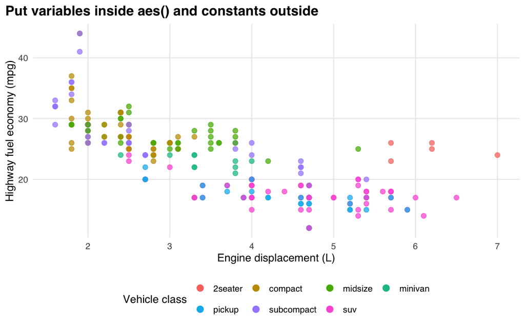

Figure 2: Color is mapped to vehicle class; alpha and point size are fixed.

```r
ggplot(mpg, aes(displ, hwy)) +
  geom_point(aes(color = class), alpha = 0.72, size = 2.2) +
  labs(
    title = "Put variables inside aes() and constants outside",
    color = "Vehicle class",
    x = "Engine displacement (L)",
    y = "Highway fuel economy (mpg)"
  ) +
  guides(color = guide_legend(nrow = 2, byrow = TRUE,
                              override.aes = list(alpha = 1, size = 3)))
```

One of the most common mistakes is `aes(color = "steelblue")`. It treats the string as a category and creates a legend rather than setting points to blue.

```r
# Wrong: treats "steelblue" as a data category
ggplot(mpg, aes(displ, hwy)) + geom_point(aes(color = "steelblue"))

# Correct: fixes every point to the same blue
ggplot(mpg, aes(displ, hwy)) + geom_point(color = "steelblue")
```

## 2.3 Global mappings, local mappings, and grouping

Here, point color is mapped to vehicle class while trend lines are grouped only by drive type (`drv`). `group` controls which observations belong to one line, and `show.legend = FALSE` hides the trend-line guide.

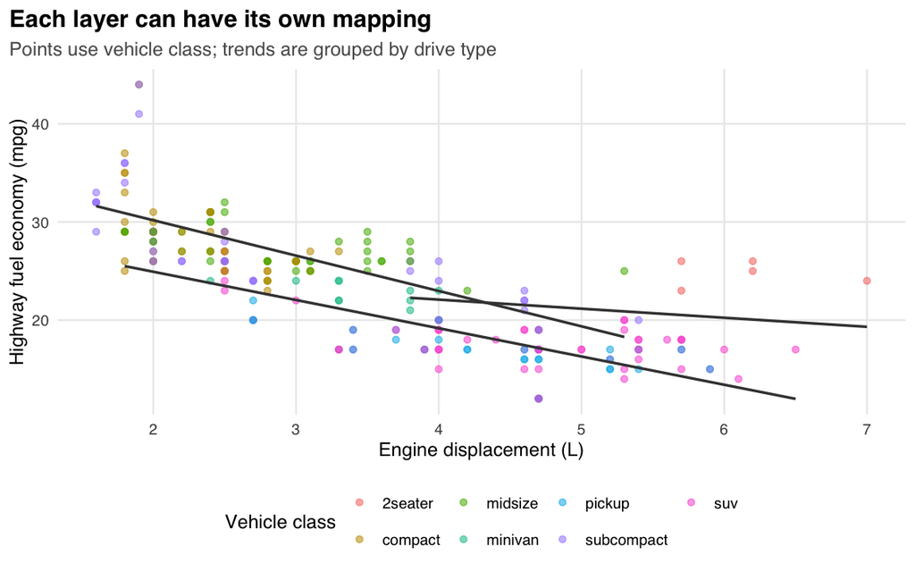

Figure 3: Local mappings let layers use different grouping rules.

```r
ggplot(mpg, aes(displ, hwy)) +
  geom_point(aes(color = class), alpha = 0.55) +
  geom_smooth(
    aes(group = drv),
    method = "lm", formula = y ~ x,
    se = FALSE, color = "grey25", linewidth = 0.8,
    show.legend = FALSE
  ) +
  labs(
    title = "Each layer can have its own mapping",
    subtitle = "Points use vehicle class; trends are grouped by drive type",
    color = "Vehicle class",
    x = "Engine displacement (L)",
    y = "Highway fuel economy (mpg)"
  )
```

When a layer should not inherit global mappings, use `inherit.aes = FALSE` and fully specify that layer’s own `data` and `aes()`.

# 3 Common geoms

## 3.1 Scatterplots: overplotting, transparency, and jitter

Discrete or repeated values often overlap. Common remedies are smaller points, transparency, or `geom_jitter()` to add a small visual displacement.

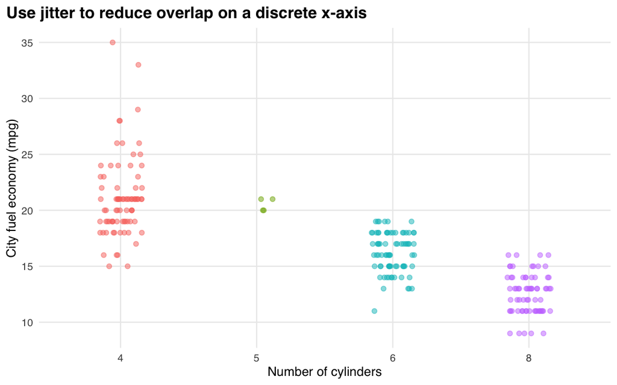

Figure 4: Jitter reveals discrete observations that would otherwise overlap.

```r
ggplot(mpg, aes(factor(cyl), cty, color = factor(cyl))) +
  geom_jitter(width = 0.16, height = 0, alpha = 0.5, size = 1.8,
              show.legend = FALSE) +
  labs(
    title = "Use jitter to reduce overlap on a discrete x-axis",
    x = "Number of cylinders",
    y = "City fuel economy (mpg)"
  )
```

`geom_jitter()` helps display individual observations, but the displacement is only a display technique and must not be interpreted as measurement error. For large data, also consider two-dimensional bins, contours, or sampling.

## 3.2 Smooths and regression lines

The default method used by `geom_smooth()` depends on data size. For a clear analytical meaning, specify the method explicitly:

- `method = "lm"`: a linear model;
- `method = "loess"`: a local smooth suitable for smaller data;
- `se = TRUE/FALSE`: show or hide the confidence band;
- `formula = y ~ x`: make the model formula explicit.

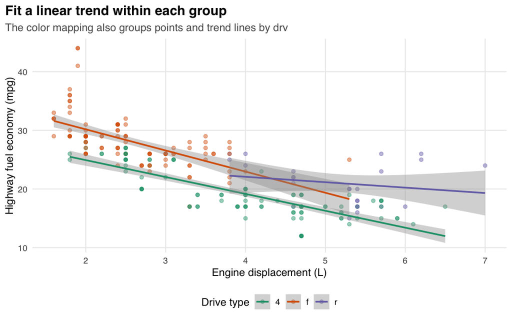

Figure 5: A scatterplot with grouped linear regression lines and confidence bands.

```r
ggplot(mpg, aes(displ, hwy, color = drv)) +
  geom_point(alpha = 0.45) +
  geom_smooth(method = "lm", formula = y ~ x, se = TRUE, linewidth = 0.9) +
  scale_color_brewer(palette = "Dark2") +
  labs(
    title = "Fit a linear trend within each group",
    subtitle = "The color mapping also groups points and trend lines by drv",
    color = "Drive type",
    x = "Engine displacement (L)",
    y = "Highway fuel economy (mpg)"
  )
```

A smooth describes association, not automatic causation. Extrapolating beyond the observed x-range is especially risky.

## 3.3 Lines and time series

`geom_line()` sorts by x before joining observations and is appropriate for time series. `geom_path()` joins rows in their existing order and is useful for trajectories. Multiple lines need the correct `group`; mapping `color` or `linetype` usually establishes groups automatically.

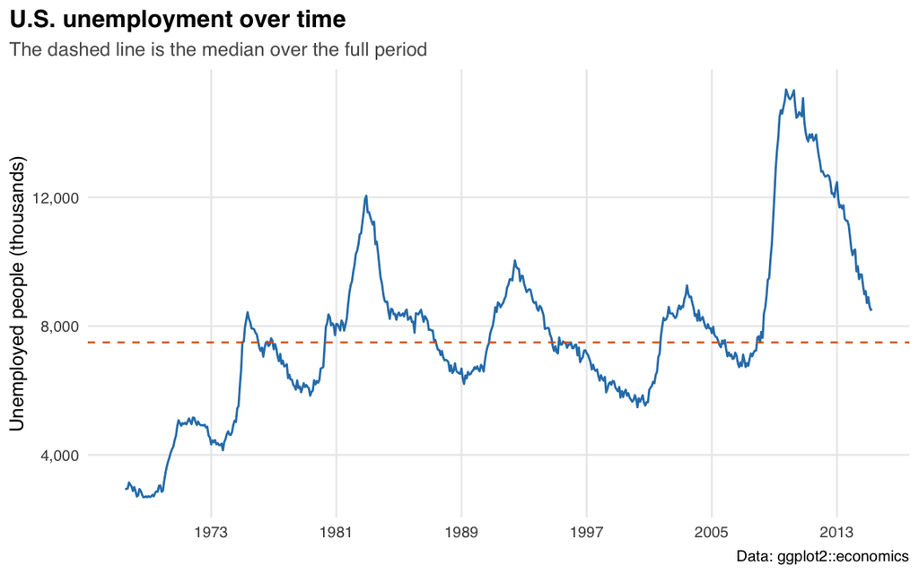

Figure 6: A time series with a reference line.

```r
unemp_median <- median(economics$unemploy, na.rm = TRUE)

ggplot(economics, aes(date, unemploy)) +
  geom_line(color = "#2c7fb8", linewidth = 0.65) +
  geom_hline(yintercept = unemp_median, linetype = "dashed", color = "#d95f0e") +
  scale_x_date(date_breaks = "8 years", date_labels = "%Y") +
  scale_y_continuous(labels = scales::label_number(big.mark = ",")) +
  labs(
    title = "U.S. unemployment over time",
    subtitle = "The dashed line is the median over the full period",
    x = NULL,
    y = "Unemployed people (thousands)",
    caption = "Data: ggplot2::economics"
  )
```

A time variable should be a `Date` or date-time object rather than an ordinary string. For grouped time series, also verify that observations are sorted by time within every group.

## 3.4 Bars: `geom_bar()` versus `geom_col()`

These functions look similar but express different data semantics:

- `geom_bar()`: supply x or y only; the default `stat = "count"` counts rows in each category;
- `geom_col()`: supply both a category and a value; it draws values that have already been computed.

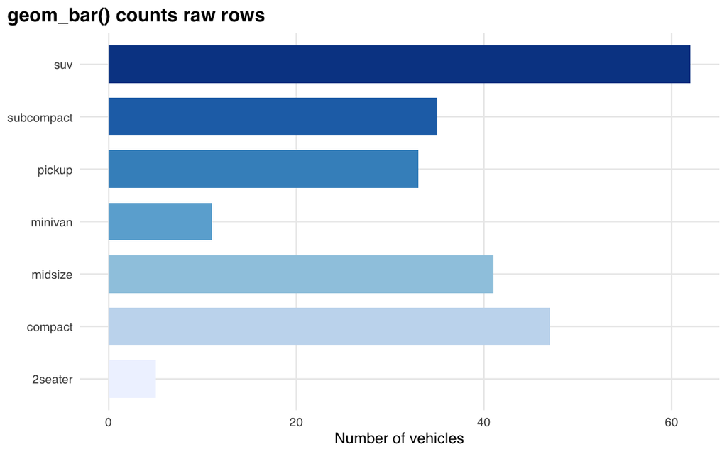

Figure 7: geom_bar() automatically counts observations in each vehicle class.

```r
ggplot(mpg, aes(y = class, fill = class)) +
  geom_bar(show.legend = FALSE, width = 0.72) +
  scale_fill_brewer(palette = "Blues") +
  labs(
    title = "geom_bar() counts raw rows",
    x = "Number of vehicles",
    y = NULL
  )
```

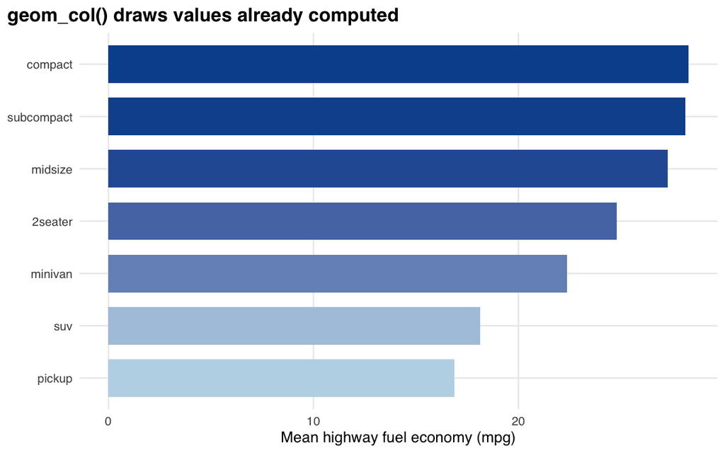

Figure 8: geom_col() draws a precomputed average for each category.

```r
class_mean <- aggregate(hwy ~ class, data = mpg, FUN = mean)
class_mean$class <- reorder(class_mean$class, class_mean$hwy)

ggplot(class_mean, aes(hwy, class, fill = hwy)) +
  geom_col(width = 0.72, show.legend = FALSE) +
  scale_fill_gradient(low = "#bdd7e7", high = "#08519c") +
  labs(
    title = "geom_col() draws values already computed",
    x = "Mean highway fuel economy (mpg)",
    y = NULL
  )
```

## 3.5 Stack, dodge, and fill

`position` controls how groups at the same category are arranged:

| position | Effect | Best question |
| --- | --- | --- |
| `"stack"` | Stacks groups; the default for bars | What are the total and composition? |
| `"dodge"` | Places groups side by side | How do absolute group counts compare? |
| `"fill"` | Normalizes every bar to 100% | How do proportions compare? |
| `"identity"` | Keeps original positions and overlaps | Are coordinates precomputed or is alpha used? |

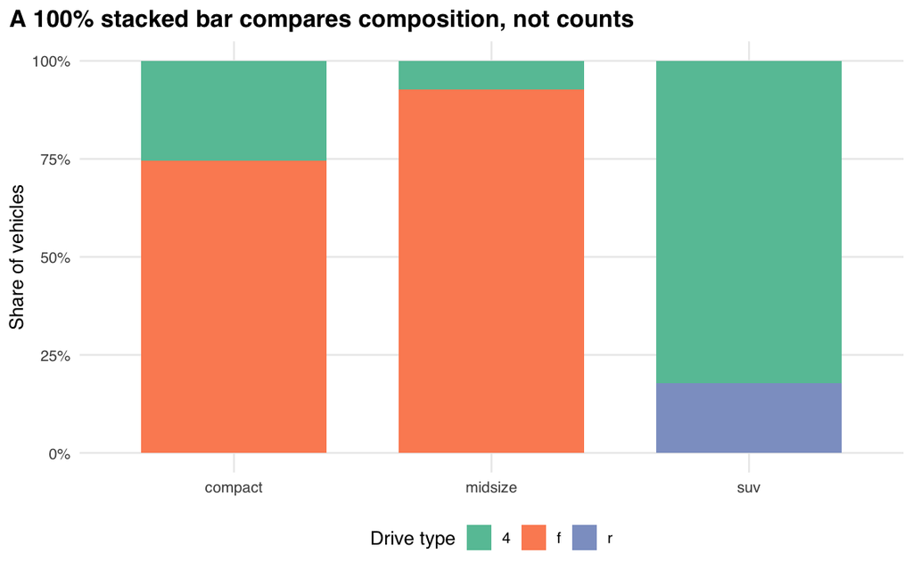

Figure 9: position = ‘fill’ compares drive-type composition within vehicle classes.

```r
mpg_three <- subset(mpg, class %in% c("compact", "midsize", "suv"))

ggplot(mpg_three, aes(class, fill = drv)) +
  geom_bar(position = "fill", width = 0.72) +
  scale_y_continuous(labels = scales::label_percent()) +
  scale_fill_brewer(palette = "Set2") +
  labs(
    title = "A 100% stacked bar compares composition, not counts",
    x = NULL,
    y = "Share of vehicles",
    fill = "Drive type"
  )
```

Percentage bars hide sample-size differences. If group totals matter, label `n` or also show a count chart.

# 4 Distributions and statistical transformations

## 4.1 Histograms and densities

A histogram’s message can change with bin width. `bins` specifies the number of bins; `binwidth` specifies each bin’s width. Try several defensible values based on measurement precision and sample size. Below, the histogram is put on a density scale before a kernel-density curve is overlaid.

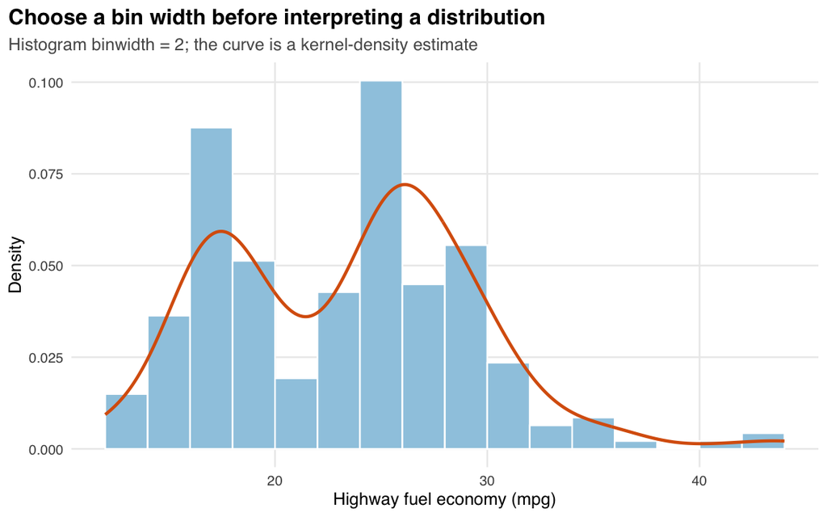

Figure 10: A density histogram and kernel-density curve for highway fuel economy.

```r
ggplot(mpg, aes(hwy)) +
  geom_histogram(
    aes(y = after_stat(density)),
    binwidth = 2, boundary = 0,
    fill = "#9ecae1", color = "white"
  ) +
  geom_density(color = "#d95f0e", linewidth = 1.05, adjust = 1) +
  labs(
    title = "Choose a bin width before interpreting a distribution",
    subtitle = "Histogram binwidth = 2; the curve is a kernel-density estimate",
    x = "Highway fuel economy (mpg)",
    y = "Density"
  )
```

`after_stat(density)` refers to a variable created by the statistical transformation. It is the modern replacement for the old `..density..` notation.

## 4.2 Boxplots and violin plots

Boxplots compactly show the median, interquartile range, and outliers; violin plots show distribution shape. When combining them, keep either layer from obscuring the other.

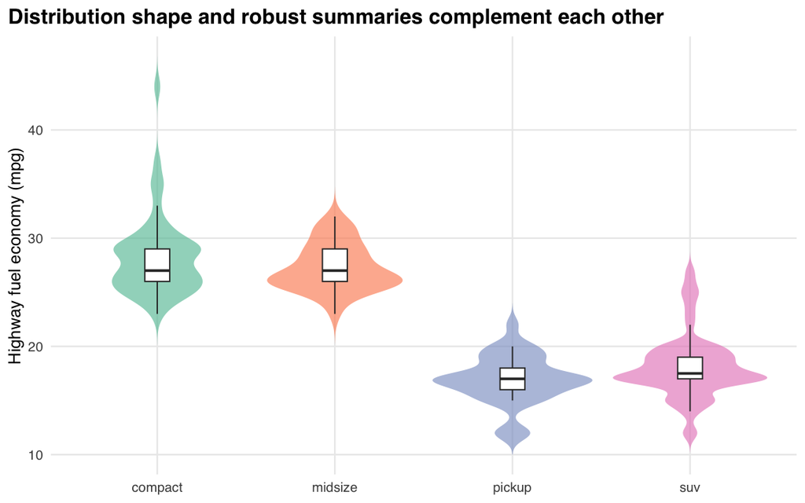

Figure 11: Violins show shape while narrow boxplots show robust summaries.

```r
mpg_four <- subset(mpg, class %in% c("compact", "midsize", "pickup", "suv"))

ggplot(mpg_four, aes(class, hwy, fill = class)) +
  geom_violin(trim = FALSE, alpha = 0.65, color = NA, show.legend = FALSE) +
  geom_boxplot(width = 0.14, outlier.shape = NA, fill = "white",
               linewidth = 0.45) +
  scale_fill_brewer(palette = "Set2") +
  labs(
    title = "Distribution shape and robust summaries complement each other",
    x = NULL,
    y = "Highway fuel economy (mpg)"
  )
```

Violin shapes can be unstable for small groups. Add jittered observations and report group sample sizes when needed. A boxplot outlier is not automatically a data error.

## 4.3 `stat_summary()`: summarize while plotting

`stat_summary()` can calculate a center and interval by x group. The point below is a mean and the range is “mean ± one standard deviation.” This is not a confidence interval, so the caption must define it accurately.

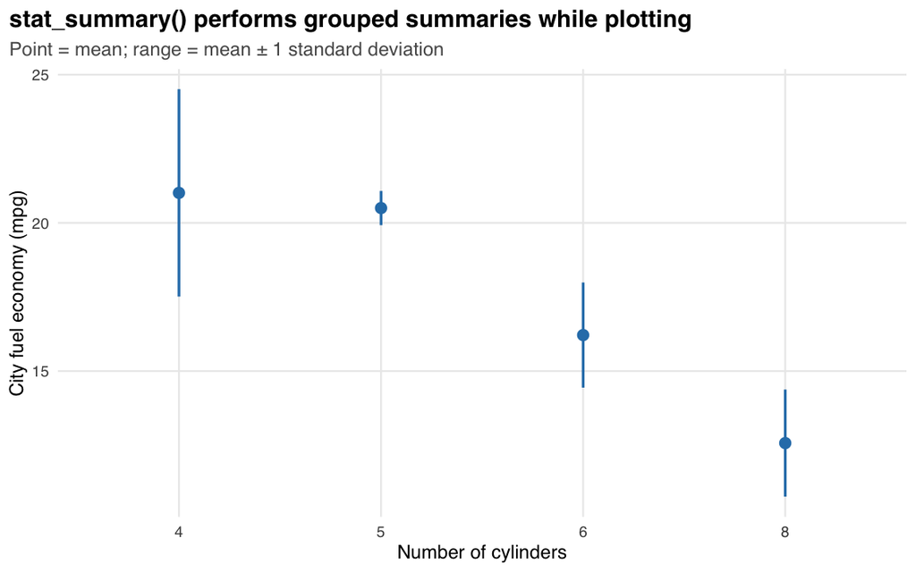

Figure 12: Mean city fuel economy and one-standard-deviation ranges by cylinder count.

```r
mean_minus_sd <- function(z) mean(z, na.rm = TRUE) - sd(z, na.rm = TRUE)
mean_plus_sd  <- function(z) mean(z, na.rm = TRUE) + sd(z, na.rm = TRUE)

ggplot(mpg, aes(factor(cyl), cty)) +
  stat_summary(
    fun = mean,
    fun.min = mean_minus_sd,
    fun.max = mean_plus_sd,
    geom = "pointrange",
    color = "#2c7fb8",
    linewidth = 0.8
  ) +
  labs(
    title = "stat_summary() performs grouped summaries while plotting",
    subtitle = "Point = mean; range = mean ± 1 standard deviation",
    x = "Number of cylinders",
    y = "City fuel economy (mpg)"
  )
```

This is convenient during exploration. For a complex formal analysis, build an explicit summary data frame first, then draw it with `geom_col()`, `geom_point()`, or `geom_errorbar()` so the calculations are easy to audit.

# 5 Facets: small multiples for group comparison

## 5.1 `facet_wrap()` and `facet_grid()`

- `facet_wrap(~ var)`: one faceting variable, wrapped into rows and columns;
- `facet_grid(rows ~ cols)`: row and column variables have distinct meaning;
- `scales = "free_y"`, and similar options: allow panel-specific scales, but weaken absolute comparisons across panels.

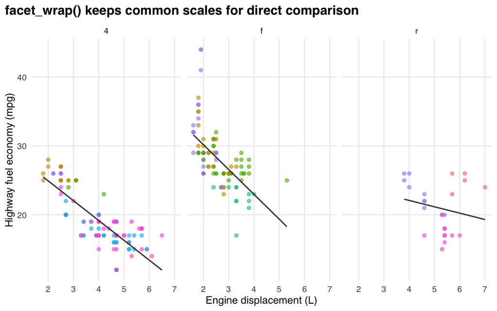

Figure 13: The displacement–economy relationship faceted by drive type.

```r
ggplot(mpg, aes(displ, hwy)) +
  geom_point(aes(color = class), alpha = 0.6, show.legend = FALSE) +
  geom_smooth(method = "lm", formula = y ~ x, se = FALSE,
              color = "grey25", linewidth = 0.7) +
  facet_wrap(~ drv, nrow = 1) +
  labs(
    title = "facet_wrap() keeps common scales for direct comparison",
    x = "Engine displacement (L)",
    y = "Highway fuel economy (mpg)"
  )
```

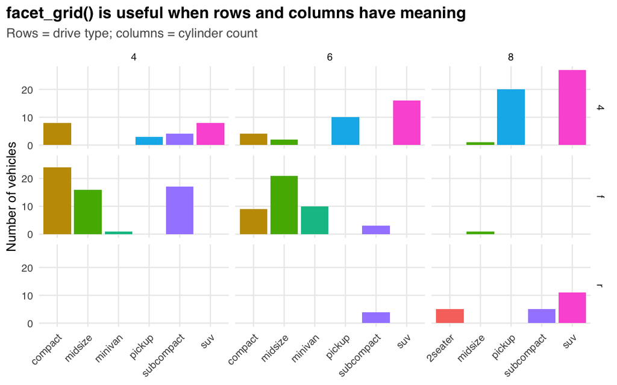

Figure 14: Row and column facets encode drive type and cylinder count.

```r
facet_data <- subset(mpg, cyl %in% c(4, 6, 8))

ggplot(facet_data, aes(class, fill = class)) +
  geom_bar(show.legend = FALSE) +
  facet_grid(drv ~ cyl, scales = "free_x", space = "free_x") +
  labs(
    title = "facet_grid() is useful when rows and columns have meaning",
    subtitle = "Rows = drive type; columns = cylinder count",
    x = NULL,
    y = "Number of vehicles"
  ) +
  theme(axis.text.x = element_text(angle = 45, hjust = 1))
```

An empty panel can be important information: it says a combination does not occur. Do not remove empty combinations merely for appearance.

# 6 Scales: controlling visual mappings

## 6.1 Continuous, discrete, and manual scales

Scale functions generally follow `scale_<aesthetic>_<type>()`, for example:

- `scale_x_continuous()` and `scale_y_log10()` for position;
- `scale_color_brewer()` and `scale_fill_viridis_d()` for discrete color;
- `scale_color_viridis_c()` and `scale_fill_gradient()` for continuous color;
- `scale_color_manual()` for manually assigned categorical colors;
- `scale_x_date()` for a date axis.

`color` usually controls points, lines, and outlines. `fill` controls the interior of bars, areas, and closed shapes.

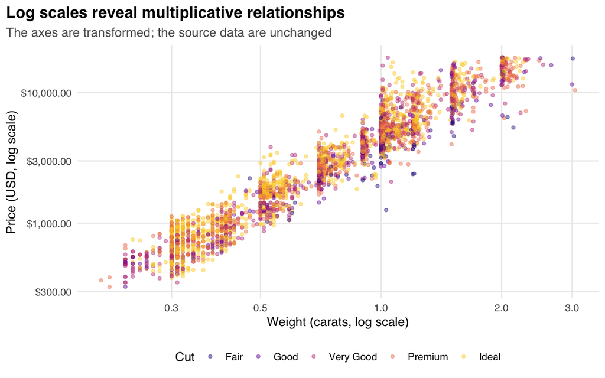

Figure 15: Diamond weight and price on logarithmic scales.

```r
diamond_sample <- diamonds[sample.int(nrow(diamonds), 3000), ]

ggplot(diamond_sample, aes(carat, price, color = cut)) +
  geom_point(alpha = 0.42, size = 1.2) +
  scale_x_log10(
    breaks = c(0.3, 0.5, 1, 2, 3),
    labels = scales::label_number()
  ) +
  scale_y_log10(labels = scales::label_dollar()) +
  scale_color_viridis_d(option = "C", end = 0.9) +
  labs(
    title = "Log scales reveal multiplicative relationships",
    subtitle = "The axes are transformed; the source data are unchanged",
    x = "Weight (carats, log scale)",
    y = "Price (USD, log scale)",
    color = "Cut"
  )
```

A log scale cannot display zero or negative values, and it changes the meaning of visual distance. State the transformation in an axis label or caption.

## 6.2 Manual colors and category order

Use a named vector for manual colors so categories are matched by name rather than by an accidental factor order.

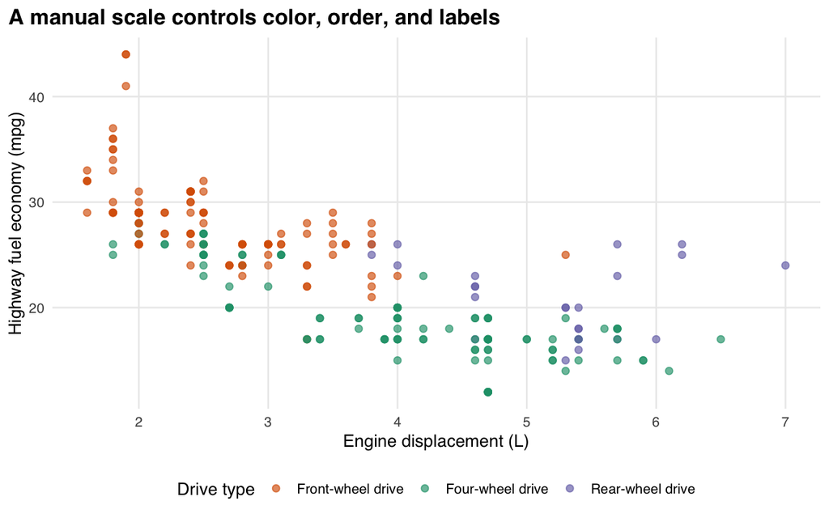

Figure 16: A named vector assigns categorical colors reliably.

```r
drive_colors <- c("4" = "#1b9e77", "f" = "#d95f02", "r" = "#7570b3")

ggplot(mpg, aes(displ, hwy, color = drv)) +
  geom_point(alpha = 0.65, size = 2) +
  scale_color_manual(
    values = drive_colors,
    breaks = c("f", "4", "r"),
    labels = c("Front-wheel drive", "Four-wheel drive", "Rear-wheel drive")
  ) +
  labs(
    title = "A manual scale controls color, order, and labels",
    x = "Engine displacement (L)",
    y = "Highway fuel economy (mpg)",
    color = "Drive type"
  )
```

Category order affects axes, stacking, and legends. Two useful base R patterns are:

```r
# Set a meaningful business order
dat$level <- factor(dat$level, levels = c("Low", "Medium", "High"))

# Reorder groups by a numerical summary
dat$group <- reorder(dat$group, dat$value, FUN = median)
```

## 6.3 `limits` versus visual zooming

This distinction can change a statistical result:

```r
# Deletes out-of-range observations before statistical computation;
# smooths, boxplots, and other summaries may change
p + scale_y_continuous(limits = c(20, 40))

# Changes only the viewing window and keeps all observations
p + coord_cartesian(ylim = c(20, 40))
```

Prefer `coord_cartesian()` when you only want a closer view. If filtering is analytically intended, filter explicitly before plotting so the decision is visible.

# 7 Coordinate systems, labels, and annotations

## 7.1 Coordinate systems

- `coord_cartesian()`: zoom without deleting observations;
- `coord_fixed(ratio = 1)`: fix the physical ratio of x and y units;
- `coord_flip()`: swap axes in older code; current ggplot2 usually favors swapping x and y directly in `aes()`;
- `coord_polar()`: polar coordinates for pie or ring charts, although angles and areas are hard to compare accurately.

Coordinates are applied after scales. When exact comparisons matter, position and length are usually easier to read than angle or area.

## 7.2 Titles, labels, reference lines, and annotations

`labs()` manages titles, subtitles, axes, guide titles, and captions. `annotate()` adds one-off explanations, while `geom_text()` and `geom_label()` add labels from a data frame.

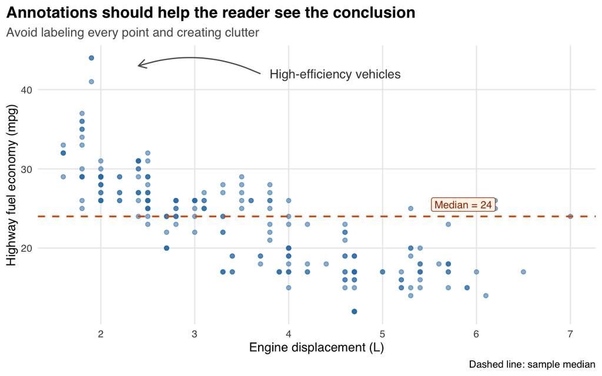

Figure 17: Reference lines and annotations emphasize a key region.

```r
hwy_median <- median(mpg$hwy)

ggplot(mpg, aes(displ, hwy)) +
  geom_point(color = "#2c7fb8", alpha = 0.55) +
  geom_hline(yintercept = hwy_median, linetype = "dashed",
             color = "#d95f0e", linewidth = 0.8) +
  annotate(
    "label", x = 6.2, y = hwy_median + 1.5,
    label = paste0("Median = ", hwy_median),
    hjust = 1, size = 3.5,
    fill = "#fff5eb", color = "#a63603"
  ) +
  annotate(
    "curve", x = 3.7, y = 42, xend = 2.4, yend = 43,
    curvature = 0.2, arrow = arrow(length = grid::unit(0.12, "inches")),
    color = "grey35"
  ) +
  annotate("text", x = 3.8, y = 42, label = "High-efficiency vehicles",
           hjust = 0, color = "grey25") +
  labs(
    title = "Annotations should help the reader see the conclusion",
    subtitle = "Avoid labeling every point and creating clutter",
    x = "Engine displacement (L)",
    y = "Highway fuel economy (mpg)",
    caption = "Dashed line: sample median"
  ) +
  coord_cartesian(clip = "off")
```

`grid::unit()` and `arrow()` come with R; no extra plotting extension is required.

# 8 Themes, legends, and reusable styling

## 8.1 What a theme controls

A theme controls **non-data elements** and does not alter data mappings. Common complete themes include `theme_minimal()`, `theme_classic()`, and `theme_bw()`. Use `theme()` for targeted changes:

- `element_text()` for text;
- `element_line()` for grid and axis lines;
- `element_rect()` for backgrounds and borders;
- `element_blank()` to remove an element.

The setup chunk defines `theme_guide()`. Wrapping a project’s visual system in a function is more reliable than copying a long `theme()` call onto every plot.

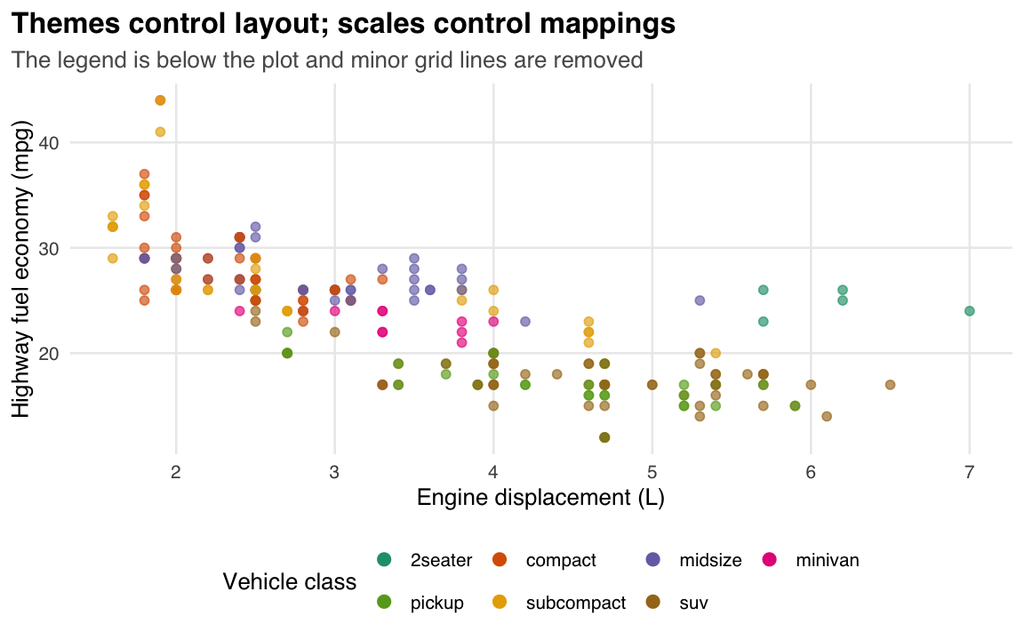

Figure 18: A reusable theme unifies type, grid, title, and legend placement.

```r
ggplot(mpg, aes(displ, hwy, color = class)) +
  geom_point(alpha = 0.65, size = 2) +
  scale_color_brewer(palette = "Dark2") +
  labs(
    title = "Themes control layout; scales control mappings",
    subtitle = "The legend is below the plot and minor grid lines are removed",
    x = "Engine displacement (L)",
    y = "Highway fuel economy (mpg)",
    color = "Vehicle class"
  ) +
  guides(color = guide_legend(nrow = 2, byrow = TRUE,
                              override.aes = list(alpha = 1, size = 3))) +
  theme_guide(base_size = 13)
```

When multiple layers map to the same variable and use the same scale name, ggplot2 usually merges their guides. Use `guides()` to adjust order, rows, or example marks, and `theme(legend.position = "none")` to remove an unnecessary legend.

# 9 Two-dimensional summaries: heatmaps

When both axes are categorical and a cell represents a count or value, `geom_tile()` is a useful choice.

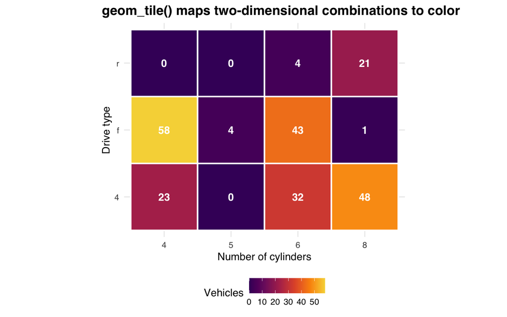

Figure 19: Heatmap of vehicle counts by cylinder count and drive type.

```r
heat <- as.data.frame(table(cyl = mpg$cyl, drv = mpg$drv))

ggplot(heat, aes(cyl, drv, fill = Freq)) +
  geom_tile(color = "white", linewidth = 0.8) +
  geom_text(aes(label = Freq), color = "white", fontface = "bold") +
  scale_fill_viridis_c(option = "B", begin = 0.2, end = 0.9) +
  labs(
    title = "geom_tile() maps two-dimensional combinations to color",
    x = "Number of cylinders",
    y = "Drive type",
    fill = "Vehicles"
  ) +
  coord_fixed()
```

A continuous palette should have a perceptually consistent progression in lightness. Viridis palettes are generally friendly to common color-vision differences and grayscale printing. If labels disappear on light cells, choose text color conditionally from the fill value.

# 10 Using ggplot2 inside functions

Do not use the deprecated `aes_string()`. When a function receives column names as strings, use `.data[[...]]`:

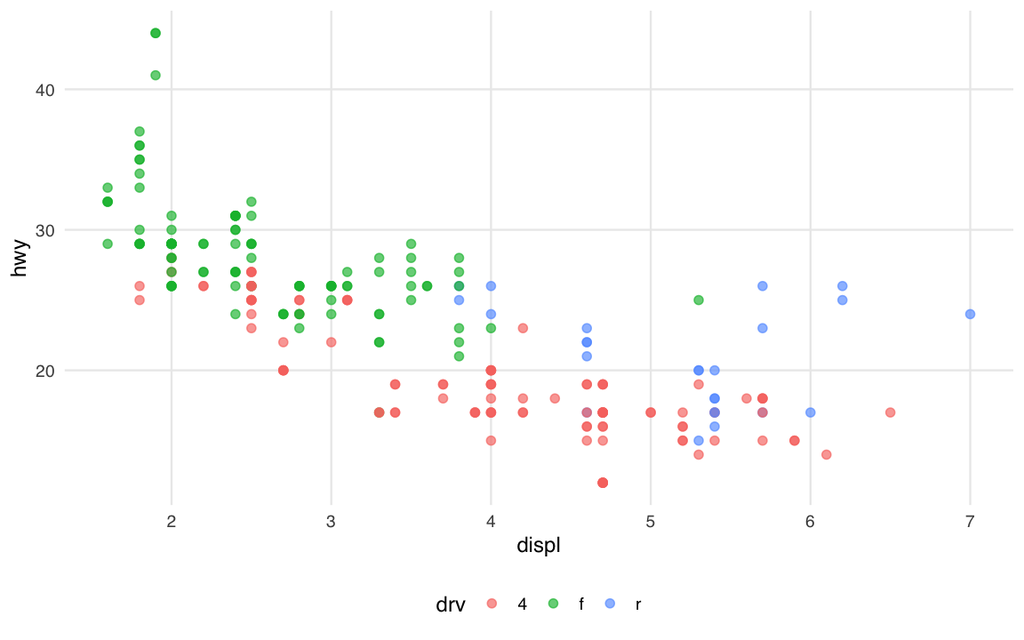

```r
make_scatter <- function(data, x, y, color = NULL) {
  if (is.null(color)) {
    mapping <- aes(x = .data[[x]], y = .data[[y]])
  } else {
    mapping <- aes(
      x = .data[[x]],
      y = .data[[y]],
      color = .data[[color]]
    )
  }

  ggplot(data, mapping) +
    geom_point(alpha = 0.65, size = 2) +
    labs(x = x, y = y, color = color) +
    theme_guide()
}

make_scatter(mpg, "displ", "hwy", "drv")
```

The function returns a ggplot object, so callers can keep adding layers:

```r
make_scatter(mpg, "displ", "hwy", "drv") +
  geom_smooth(method = "lm", formula = y ~ x) +
  labs(title = "A plot returned by a function remains extensible")
```

# 11 Exporting high-quality figures

`ggsave()` saves the last displayed plot by default. Passing `plot` explicitly is safer in scripts and functions. Width, height, and `dpi` jointly determine raster image dimensions.

```r
p <- ggplot(mpg, aes(displ, hwy, color = drv)) +
  geom_point(alpha = 0.7) +
  labs(x = "Engine displacement (L)", y = "Highway MPG") +
  theme_guide()

# PNG for documents or the web: 7 by 4.5 inches at 300 dpi
ggsave(
  filename = "mpg_scatter.png",
  plot = p,
  width = 7, height = 4.5, units = "in",
  dpi = 300, bg = "white"
)

# Vector PDF for papers and downstream layout
ggsave("mpg_scatter.pdf", p, width = 7, height = 4.5, units = "in")
```

Practical recommendations:

- Web: PNG at 120–180 dpi is often enough; use 300 dpi for high-quality print;
- Mostly lines and text: use vector PDF or SVG;
- Many transparent points: PNG is often much smaller than a vector file;
- Set `width`, `height`, `units`, and `bg` explicitly for consistent output;
- Check type sizes at the final display dimensions, not only in a zoomed RStudio preview.

# 12 Common problems and a debugging checklist

| Symptom | Likely cause | Fix |
| --- | --- | --- |
| A strange legend contains a color name | A constant was put inside `aes()` | Put `color = "red"` outside `aes()` |
| Bars are gray or their interiors do not change | `color` and `fill` were confused | Bar and area interiors usually use `fill` |
| `geom_bar()` reports a y-related error | Count bars were used for summarized values | Use `geom_col()` |
| Separate lines are joined together | Grouping is missing | Map `group`, `color`, or `linetype` |
| A smooth or boxplot changes after zooming | `scale_* (limits=...)` removed data | Use `coord_cartesian()` for visual zooming |
| Points form a dark blob | Overplotting | Use smaller points, alpha, jitter, bins, or sampling |
| A histogram conclusion is unstable | Default bins were accepted blindly | Set and compare domain-relevant `binwidth` values |
| Category order is illogical | Character/factor defaults are being used | Set `factor(levels=...)` or use `reorder()` |
| Legends repeat or refuse to merge | Layers use different variables or scale names | Align mapping variables and `labs(color/fill=...)` |
| “Removed … rows” warning | Missing values, out-of-range values, or scale limits | Inspect `is.na()`, ranges, and `limits` |

Do not add `na.rm = TRUE` merely to silence a warning. First determine why values are missing, whether deletion is appropriate, and whether deletion changes the conclusion.

# 13 Quick selection guide

| Analytical goal | First-choice layer | Common additions |
| --- | --- | --- |
| Relationship between two continuous variables | `geom_point()` | `alpha`, `geom_smooth()` |
| Continuous value over time | `geom_line()` | `geom_point()`, reference lines |
| Category frequencies | `geom_bar()` | `position`, horizontal y mapping |
| Pre-summarized category values | `geom_col()` | Ordering, error bars |
| One-variable distribution | `geom_histogram()` / `geom_density()` | Explicit `binwidth` / `adjust` |
| Comparing grouped distributions | `geom_boxplot()` / `geom_violin()` | Jittered points, sample sizes |
| Values for two categorical dimensions | `geom_tile()` | Continuous fill scale, labels |
| Repeated comparisons across groups | `facet_wrap()` / `facet_grid()` | Shared scales |

# 14 A reliable plotting workflow

1. Confirm the unit of analysis, missingness, variable types, and reasonable ranges.
2. Draw raw data with the simplest geom; inspect outliers and overlap first.
3. Add grouping, statistical summaries, or facets; avoid mapping too many aesthetics at once.
4. Choose scales, category order, axis range, and color palette deliberately.
5. Write a conclusion-oriented title, complete axis labels and units, a guide title, and data source.
6. Check readability, color-vision accessibility, and grayscale output at the final size.
7. Export with fixed dimensions and format using `ggsave()`, and retain the plotting code and session information.

# 15 Version and reproducibility information

This document uses modern ggplot2 syntax: `linewidth` for line width, `after_stat()` for computed variables, and `.data[[...]]` in programmatic mappings.

```r
cat("R:", R.version.string, "\n")
```

```
#> R: R version 4.6.1 (2026-06-24)
```

```r
cat("ggplot2:", as.character(packageVersion("ggplot2")), "\n")
```

```
#> ggplot2: 4.0.3
```

```r
cat("knitr:", as.character(packageVersion("knitr")), "\n")
```

```
#> knitr: 1.51
```

```r
cat("rmarkdown:", as.character(packageVersion("rmarkdown")), "\n")
```

```
#> rmarkdown: 2.31
```

You have now covered ggplot2’s most common grammar, geoms, statistical transformations, positions, facets, scales, coordinates, themes, annotations, programming interface, and export workflow. In real projects, make the data meaning and comparison task clear before adding visual decoration.